# Spracovanie a analýza dát spoločnosti Yelp

Jakub Hrbáň

# Obsah prezentácie

- Predstavenie dát
- Úvodné komplikácie a ich riešenie
- Analýza dát - biznis pohľad
- NLP + vizualizácie
- ML + interpretácia výsledkov
- Záver

# Predstavenie dát

- Recenzie spoločností z oblasti služieb, gastronómie a voľnočasových aktivít
- Dáta získané zo stránky spoločnosti [Yelp](https://www.yelp.com/dataset) - celosvetová firma zameraná na uverejňovanie recenzií od používateľov
- 6 datasetov:
  - o spoločnostiach
  - o používateľoch
  - recenzie používateľov
  - fotografie od používateľov z miesta činu
  - tipy - kratšie ako recenzie
  - zaznamenané check-iny používateľov

# Úvodné komplikácie a ich riešenie

- Dáta vo formáte .json
- Komplikovaná štruktúra na spracovanie dát $\rightarrow$ potrebná transformácia
- Problém s pamäťou pri načítaní datasetov o zákazníkoch a používateľoch - veľkosť súborov
- Riešenie: použitie distribuovaného prostredia na transformáciu formátu .json do viacerých menších .csv súborov

## Spark - distribuované prostredie

- Efektívnejšia práca s datasetmi
- Možnosť paralelných výpočtov
- Zapojenie viacerých jadier naraz

# Analýza dát - biznis pohľad

- Bližší náhľad na recenzie reštaurácií - vysoká možná pridaná hodnota
- Vybrané len tie, ktoré sú aktuálne otvorené
- Úprava zle zaradených reštaurácií podľa miesta výskytu - robilo problémy pri vizualizácii

## Analýza dát - biznis pohľad

- Vizualizácia agregovaného počtu reštaurácií v rámci jednotlivých štátov

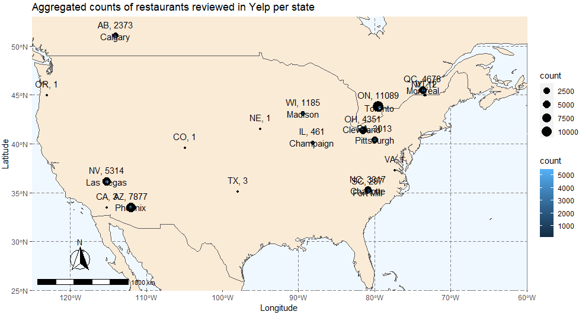

## Analýza dát - biznis pohľad

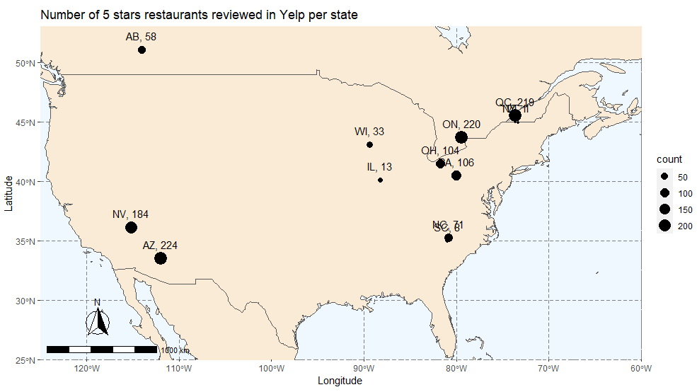

## Analýza dát - biznis pohľad

- Zoznam najväčších influencerov vzhľadom na počet užitočných recenzií (označené inými užívateľmi), počet fanúšikov a pomeru užitočných recenií/počet recenzií

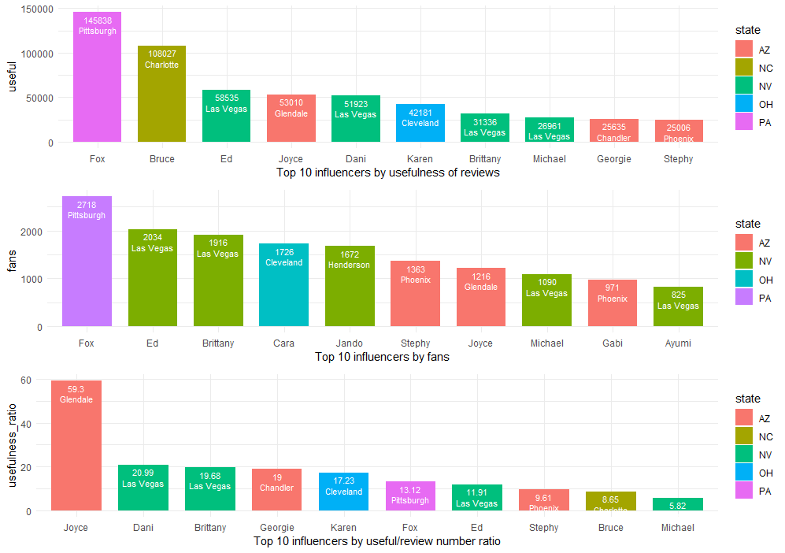

# NLP + vizualizácie

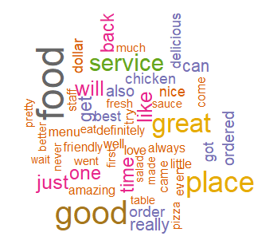

## NLP + vizualizácie

- Výzva: spracovanie textových dát za účelom vyťaženia užitočných informácií pre reštaurácie
- Filtrovanie recenzií vzhľadom na reštaurácie
- NLP workflow:

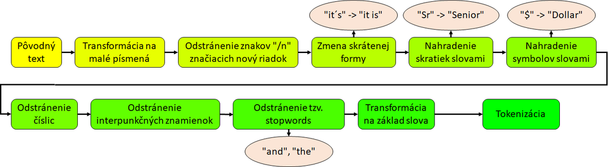

## NLP + vizualizácie

- Uvedenie konkrétneho príkladu z dát

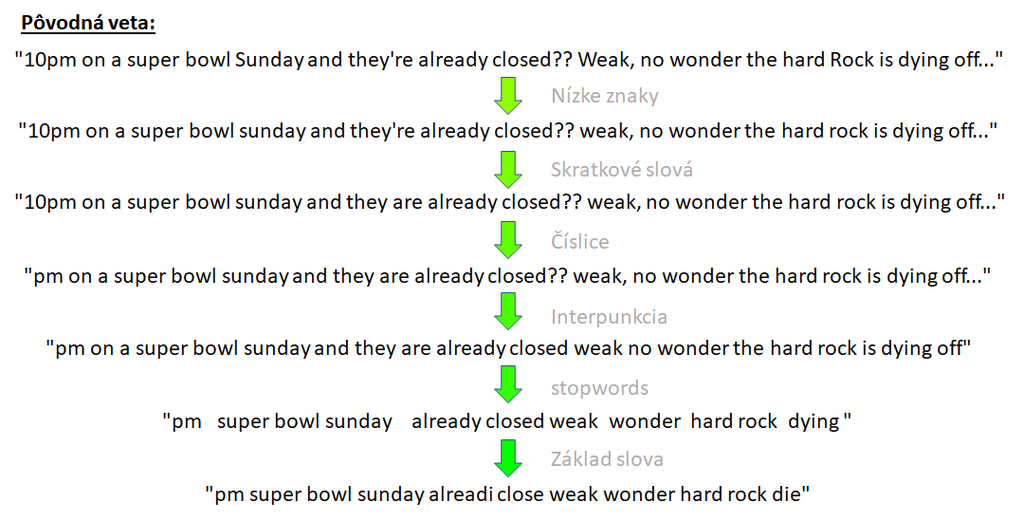

## NLP + vizualizácie

- Na tokenizáciu použité dve metódy:
  - tf $\rightarrow$ term-frequency: početnosť slov vrámci vety
  - tf_idf $\rightarrow$ term-frequency inverse document frequency: prevrátená početnosť slov naprieč všetkými dokumentami
- Výhoda druhej metódy v prípade, že sa snažíme hľadať unikátne použité výrazy

## NLP + vizualizácie

- 10 najčastejšie používaných slov v závislosti od počtu rozdaných hviezdičiek reštauráciam užívateľmi

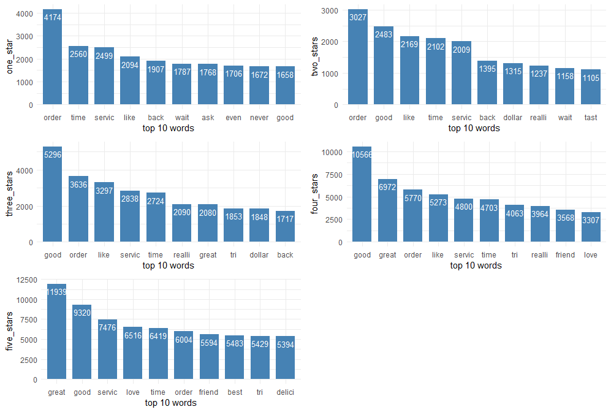

## NLP + vizualizácie

- 10 najčastejšie používaných slov v rámci rozdaných hviezdičiek reštauráciam, ak v tej kategórii bolo slovo najfrekventovanejšie

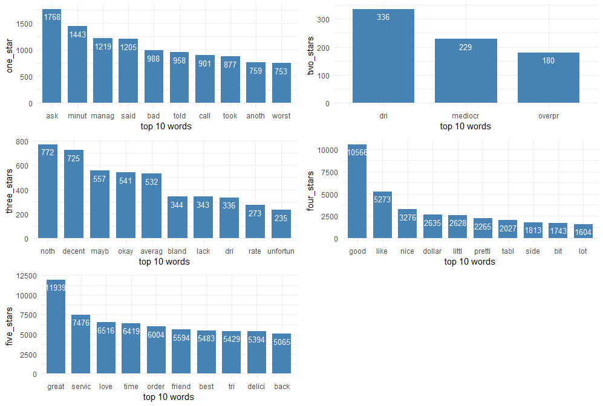

# ML + interpretácia

- Použitie výstupných dát z metód tf, respektíve tf_idf + pridanie 3 premenných hodnotiace danú recenziu
- Snaha klasifikácie dát podľa hodnotenia hviezdičkami
- Použitie nasledovných metód strojového učenia:
  - random forest
  - xgboost
  - logistická regresia
  - neurónová sieť
- Hodnotiace metriky:
  - accuracy: počet úspešne zaradených/ všetky pozorovnia (snaha dosiahnuť čo najvyššiu)
  - cross-entropy: metrika značiaca ne/istotu zaradenia (snaha dosiahnuť čo najnižšiu)

## ML + interpretácia

- Výsledky úspešnosti ML metód
- S použitím tf metódy

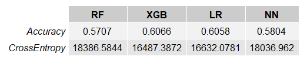

- S použitím tf_idf metódy

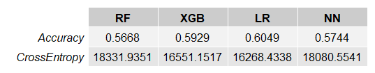

## ML + interpretácia

- dôležitosť premenných určených metódou **random forest**

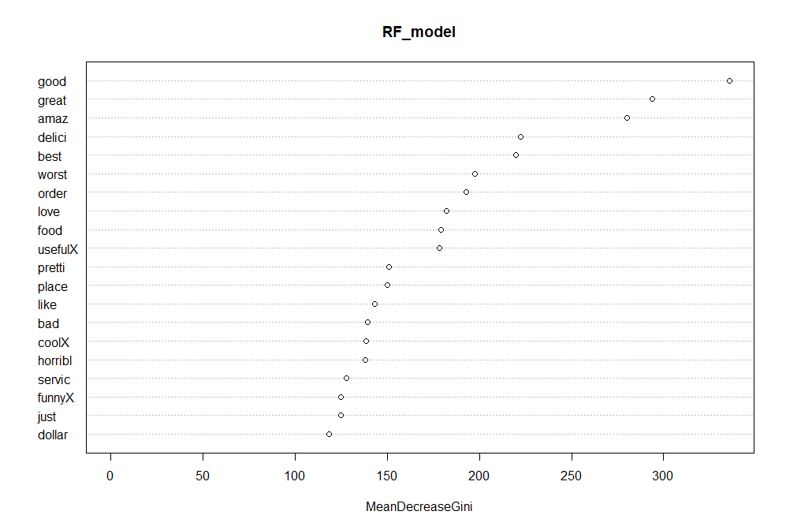

## ML + interpretácia

- dôležitosť premenných určených metódou **xgboost**

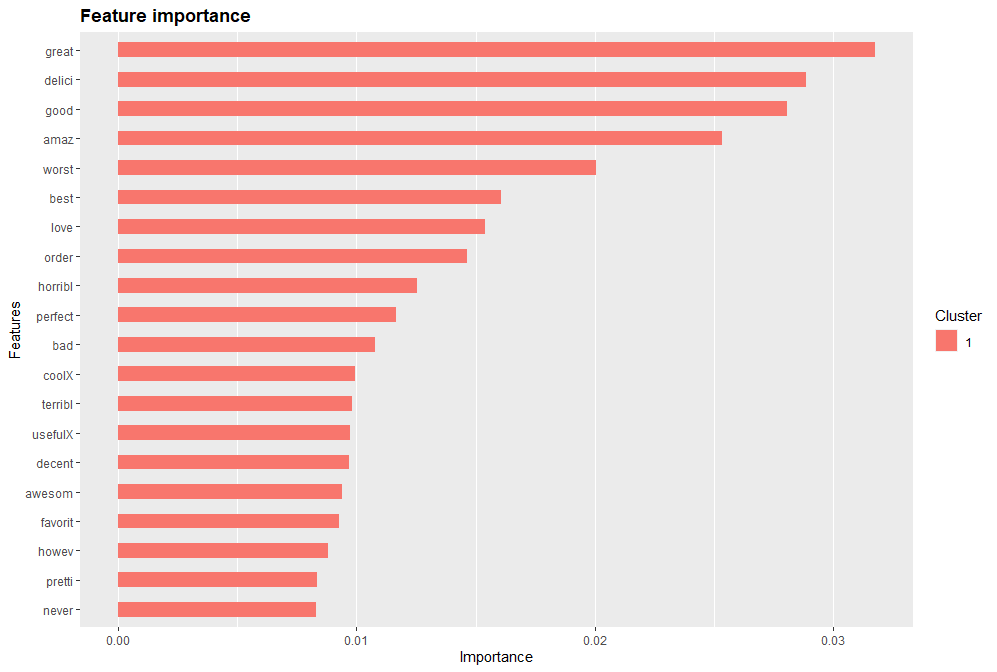

## ML + interpretácia

- dôležitosť premenných určených metódou **logistická regresia**

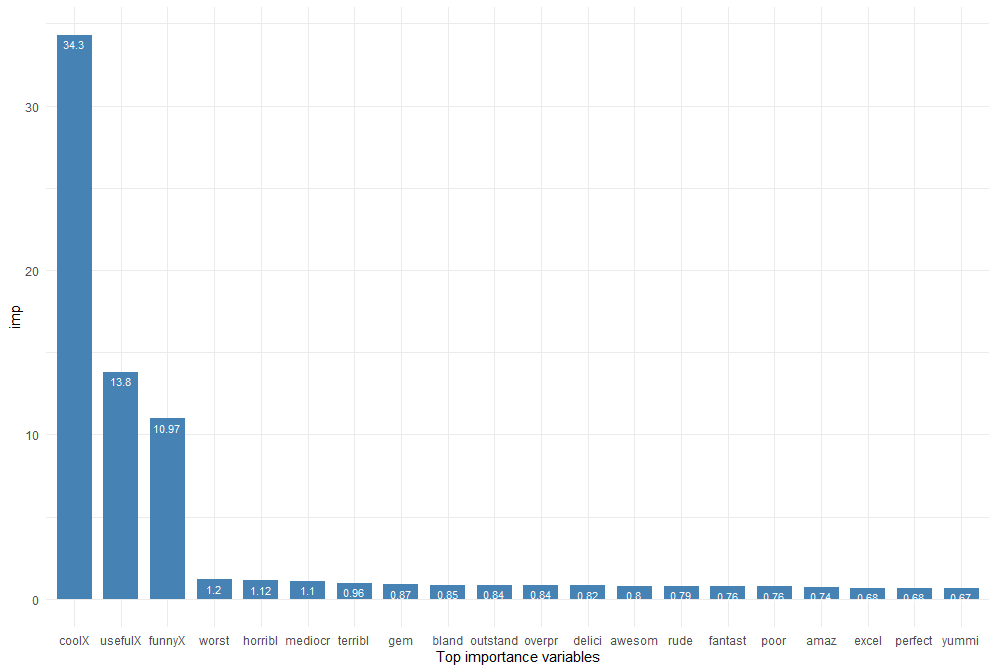

## ML + interpretácia

- dôležitosť premenných určených metódou **neurónová sieť**

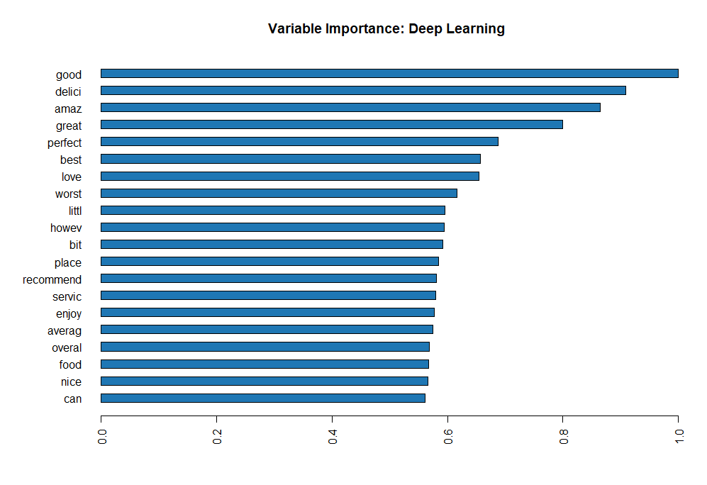